# A3: Incarceration

### Introduction

An introduction of the problem domain and a description of the variable(s) you are choosing to analyze (and why!)

```
The data tool (trends.vera.org) is used for collecting the population of prison
and jail in country-levels to better understnad the situation of the U.S.
nowadays. The problem domain is an analysis of incarceration trend in the
U.S..

I have chosen part of the dataset which is [Smaller dataset about prison/jail
population per 100,000 people (rate) per county/state starting at 1990 in Washington]
(https://github.com/melaniewalsh/Neat-Datasets/raw/main/us-prison-jail-rates-1990-WA.
csv), the last link in README.md file. Personally, I think the variables I am
choosing are clear and comprehensive, the data includes the population rate of
various types of people, such as race, sex, and so on. The population rate
is calculated by Rate per 100,000 people= (Population Count/Total Population)
* 100,000, so the unit is 0.01, and we can interpret them as each unit represents
1 in 100,000.
```

### Summary Information

Write a summary paragraph of findings that includes the 5 values calculated from your summary information R script

These will likely be calculated using your DPLYR skills, answering questions such as:

Feel free to calculate and report values that you find relevant. Again, remember that the purpose is to think about how these measure of incarceration vary by race.

Here are the values:

```
## # A tibble: 1 × 3
##    year mean_jail mean_prison
##   <int>     <dbl>       <dbl>
## 1  2016      326.        451.
```

```
## # A tibble: 1 × 3
##    year mean_jail mean_prison
##   <int>     <dbl>       <dbl>
## 1  1990      223.        257.
```

```
## # A tibble: 1 × 2
##   county_name         max_black_rate
##   <chr>                        <dbl>
## 1 Pend Oreille County          31000
```

```
## # A tibble: 1 × 2
##   county_name   max_white_rate
##   <chr>                  <dbl>
## 1 Yakima County           865.
```

```
## # A tibble: 1 × 2
##   county_name      max_aapi_rate
##   <chr>                    <dbl>
## 1 Wahkiakum County         41750
```

```
## # A tibble: 1 × 2
##   county_name         max_latinx_rate
##   <chr>                         <dbl>
## 1 Pend Oreille County           2627.
```

```
## # A tibble: 1 × 2
##   county_name  change_total_pop_rate
##   <chr>                        <dbl>
## 1 Ferry County                  452.
```

```
## # A tibble: 1 × 2
##   county_name     change_total_pop_rate
##   <chr>                           <dbl>
## 1 Franklin County                 -200.
```

```
- As a summary paragraph for the information, I can say that by comparing the
average total jail population rate of year 1990 with 2016, I can conclude that
there is an increase of population in the past few years. For races, Asian, Black
and Latinx all have significantly higher jail population rate than White one,
so there maybe racial problem, but we cannot make an exact conclusion only based
on this. Moreover, by observing the max and min changes in total jail population
rate from 1990 to 2016, the maximum is 451.95 and minimum is -200.25, we know
that even though the overall trend is increasing, there are still some counties
have a decreasing trend of incarceration.
```

### The Dataset

Who collected the data?

```
- The data was compiled by Census of Jails, Census of State and Federal
Adult CorrectionalFacilities, FBI Uniform Crime Reporting Program, National
Corrections Reporting Program, Deaths in Custody Reporting Program, Annual
Survey of Jails, Centers on Disease Control, U.S. Department of Agriculture,
and U.S. Census Bureau. Many organizations combined and cooperated together.
```

How was the data collected or generated?

```
- The data was combined by many organization's cooperation, and they
supplemented it with additional data and information when there are some
vacant blanks.
```

Why was the data collected?

```
- The data was collected for understand and know the incarceration trends
at county-levels in the U.S. comprehensively. Thus, we can a broad range
of understanding in jail and prison population but lack the specific and
exact data.
```

How many observations (rows) are in your data?

```
 - There are 1131 observations (rows).
```

How many features (columns) are in the data?

```
- There are 23 features (columns).
```

What, if any, ethical questions or questions of power do you need to consider when working with this data?

```
- I think we should treat this data seriously, even though there is a big
difference in population rate between difference races, we cannot simply
conclude there is a racism or racial problem, because the situation is much
complex. Also, high population rate is not a good thing in this data, so
we expect the data has decreasing trend, which means the U.S. may be safer.
```

What are possible limitations or problems with this data? (at least 200 words)

```
- Firstly, there are lots of missing values in the dataset, which means the
data collection lack comprehensive and accurate, so the final this may influence
the final analysis of data. Secondly, as we can see there are lots of organizations
engaged in this collection, but it is hard to make sure each of the organization
has exactly the same rules and criteria on data collecting, not to mention
the different members in each organization. Thus, there may be some bias or
error inside. Thirdly, in the codebook of this incarceration trends, there
are only descriptions of variables but no calculation or explanation of how
they get the value, such as the population rate in the last dataset. For
the population rate, at first, I didn’t know what is the formula of this
calculation, and it seems strange to me that most of the data are larger than
100, which rarely happened in most of the percentage. Also, I didn’t understand
what is the meaning of unit is 0.01, so I think the explanation should be more
clear and comprehensive. Finally, I think the data should be more detailed,
not only classify them into races and sex, but also other features of people,
so that we can analyze them in a more precise way.
```

### Trends Over Time Chart

Include a chart. Make sure to describe why you included the chart, and what patterns emerged

The first chart that you will create and include will show the trend over time of your variable/topic. Think carefully about what you want to communicate to your user (you may have to find relevant trends in the dataset first!). Here are some requirements to help guide your design:

- Show more than one, but fewer than ~10 trends
  - This may mean showing the same measure for different locations or different racial groups. Think carefully about a meaningful comparison of locations (e.g., the top 10 counties in a state, top 10 states, etc.)
- You must have clear x and y axis labels
- The chart needs a clear title
- You need a legend for your different line colors and a clear legend title

When we say “clear” or “human readable” titles and labels, that means that you should not just display the variable name.

Here is the trends over time chart (chart 1):

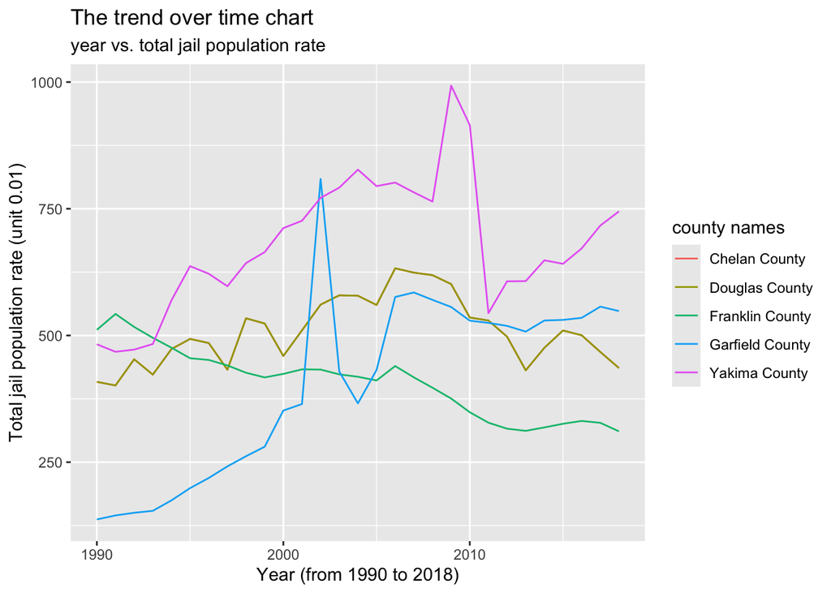

[output not shown]

### Variable Comparison Chart

Include a chart. Make sure to describe why you included the chart, and what patterns emerged

The second chart that you will create and include will show how two different (continuous) variables are related to one another. Again, think carefully about what such a comparison means and what you want to communicate to your user (you may have to find relevant trends in the dataset first!). Here are some requirements to help guide your design:

- You must have clear x and y axis labels
- The chart needs a clear title
- If you choose to add a color encoding (not required), you need a legend for your different color and a clear legend title

Here is the variable comparison chart (chart 2):

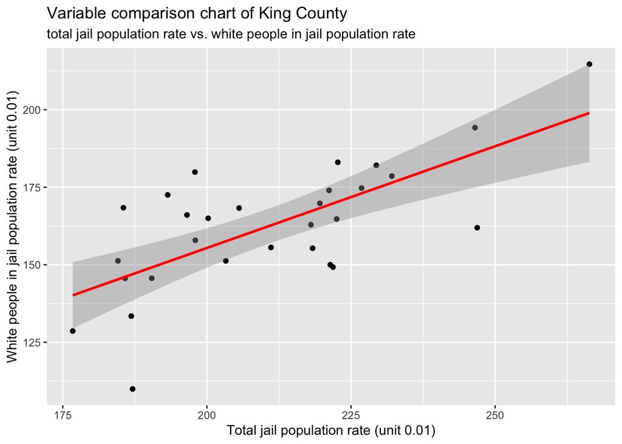

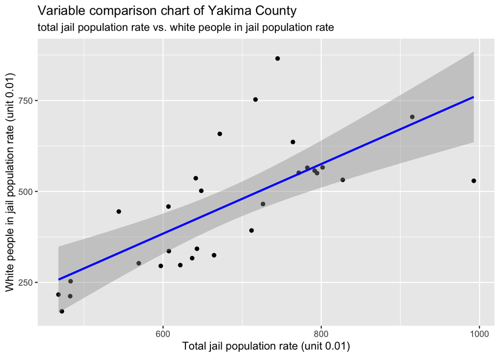

```
- I want to know whether there is a relationship between total jail population
rate and only white people's population rate in the jail, since I think white
people may take part of the proportion from the total population rate. Thus, I
have randomly chose two counties- King and Yakima- to get a conclusion, for only
one county is not persuasive enough. As we can see the two scatterplot, points
of both plots show roughly upward to the right trends, and the two line model
are increasing, so we can conclude that based on these two plots there may be
a positive relationship between total jail population rate and only white
people's population rate in the jail.
```

### Map

Include a chart. Make sure to describe why you included the chart, and what patterns emerged

The last chart that you will create and include will show how a variable is distributed geographically. Again, think carefully about what such a comparison means and what you want to communicate to your user (you may have to find relevant trends in the dataset first!). Here are some requirements to help guide your design:

- Your map needs a title
- Your color scale needs a legend with a clear label
- Use a map based coordinate system to set the aspect ratio of your map

Here is the map:

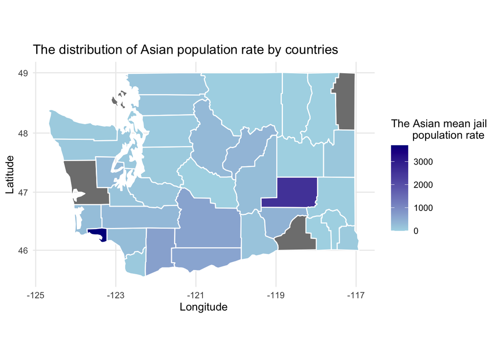

```
- Since before drawing this map, I have already analyze the data of white and
black jail population rate in the dataset, this time I want to know the
distribution of Asian jail population rate, and whether there is a
significant difference between counties. By observing the map, we can see
that the blue colors have very little difference between each other, and only
some of the parts have dark gray or blue most are lightblue. This means most
of the Asian mean jail population rates in different counties are in the range
from 0 to 1000, only few are higher than 1000 or do not have the value recorded.
Only one county has the darkest blue, which may be the maximum Asian mean
jail population rate in WA.
```